# Adventures In Golf

BT Gillard

Updated: 2021-09-20

This page is designed to keep track of our first golf membership at Thonrbury Golf Course.

# Scores over time

There are two courses at Thornbury, one full and one par 3. They are separated here. Scores over time are tracked to see if scores are improving (or not!).

[figure not shown]

Summary of our rounds as members

|  | Ben | Doug | Lew |
| --- | --- | --- | --- |
| Best | 109 | 97 | 105 |
| 1st Quartile | 120 | 106 | 110 |
| Median | 124 | 108 | 115 |
| Average | 120 | 107 | 114 |
| 3rd Quartile | 124 | 110 | 118 |
| Worst | 124 | 114 | 127 |

# Number of rounds played.

We want to make sure we use our memberships to the absolute max so it's worth tracking how many rounds we've played.

```r
#+1 par3 round that we lost the scorecard for!

RoundSummary<- rbind(Full = sapply(unique(holescoresFULL$Player), function(x) holescoresFULL %>% filter(Player == x) %>% filter(!duplicated(Date)) %>% na.omit() %>% nrow(), USE.NAMES = T), Par3 = sapply(unique(holescoresPAR3$Player), function(x) holescoresPAR3 %>% filter(Player == x) %>% filter(!duplicated(Date)) %>% na.omit() %>% nrow(), USE.NAMES = T), TotalHolesFullCourse = sapply(unique(holescoresFULL$Player), function(x) holescoresFULL %>% filter(Player == x) %>% na.omit() %>% nrow(), USE.NAMES = T), MoneySaved = sapply(unique(holescoresFULL$Player), function(x) holescoresFULL %>% filter(Player == x) %>% na.omit() %>% nrow(), USE.NAMES = T)*(34/18) + sapply(unique(holescoresPAR3$Player), function(x) holescoresPAR3 %>% filter(Player == x) %>% na.omit() %>% nrow(), USE.NAMES = T)*(15/18))

RoundSummary %>% kableExtra::kbl(caption = "Times played as members", align = "c", escape = FALSE, digits = 0) %>%  kableExtra::kable_classic(full_width = T, html_font = "Cambria")
```

Times played as members

|  | Ben | Doug | Lew |
| --- | --- | --- | --- |
| Full | 8 | 11 | 12 |
| Par3 | 2 | 1 | 1 |
| TotalHolesFullCourse | 117 | 153 | 171 |
| MoneySaved | 251 | 304 | 338 |

The formula used for working out how much our golf would have cost uses the full price of a round on the full course (£34) and the Par 3 course (15).

Cost of one hole = Full price / 18

cost of one hole x number of holes played

# Course probing

```
## $`Thornbury Long`
```

```
##
## $`Thornbury Short`
```

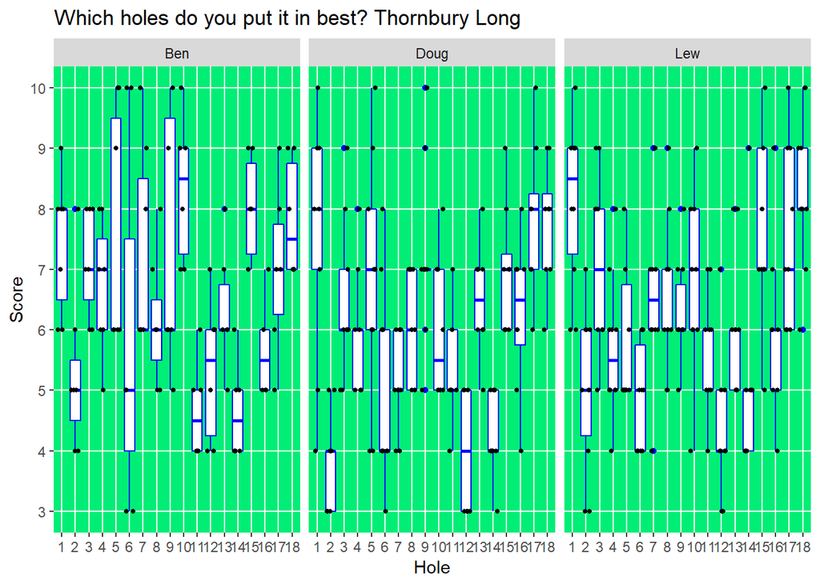

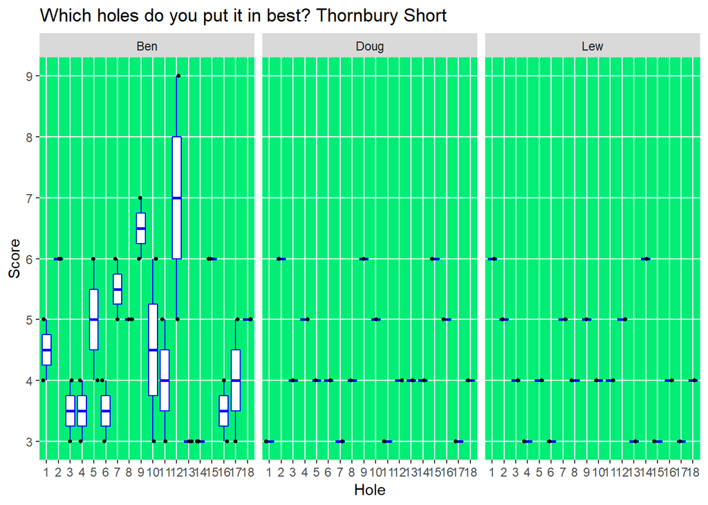

# Par performance

Some players may not be able to handle their wood but are deadly with an iron. To roughly gauge long vs short game, Par can be used to see how well our golfing warriors perform on different types of holes. Looking at overall performance on holes with different Par looks a little something like this:

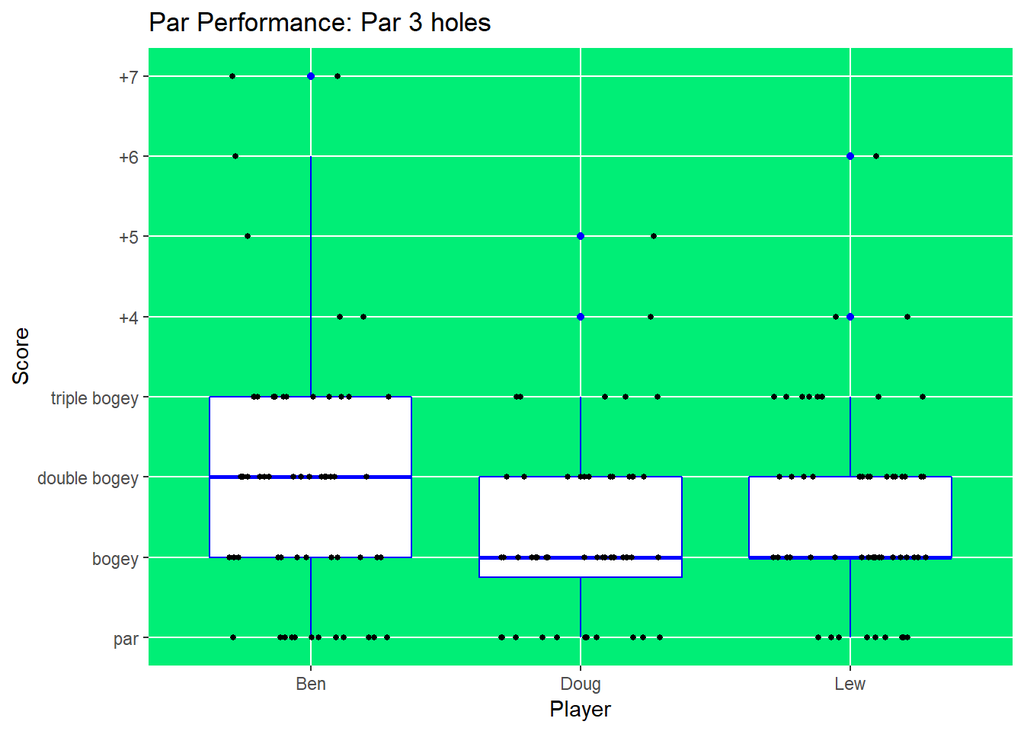

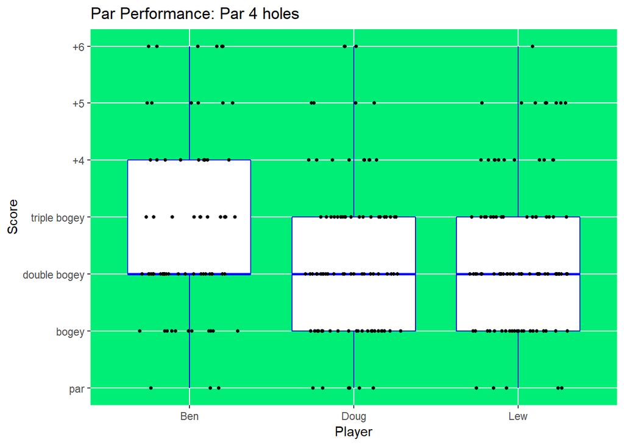

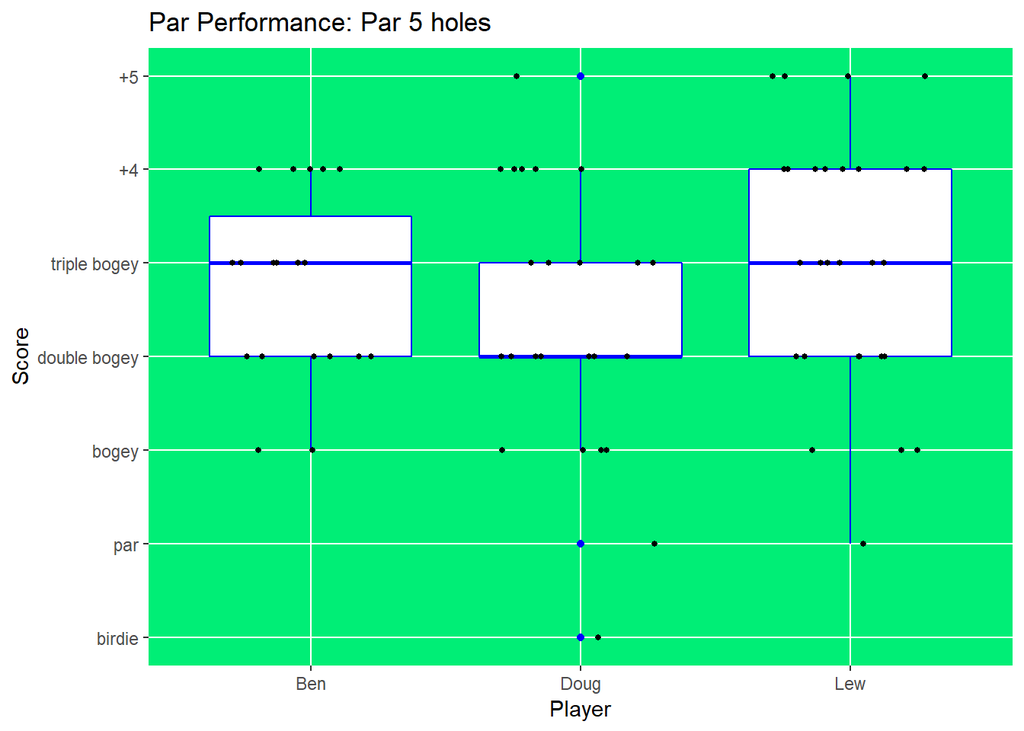

...and as histograms:

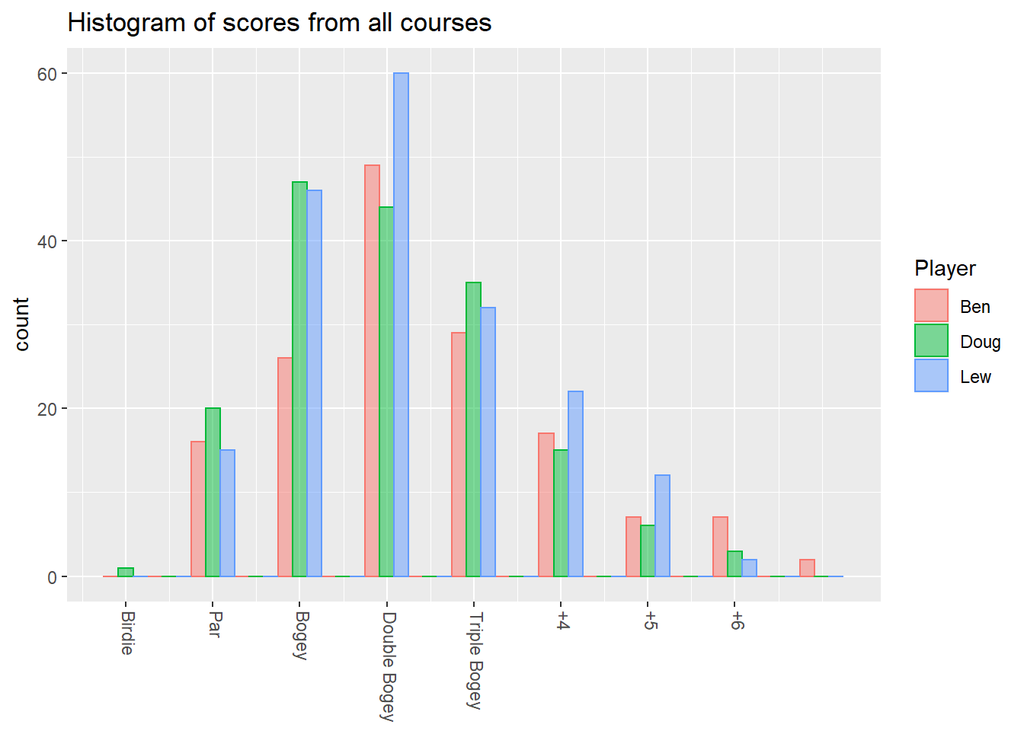

# Stats Summary

Some sweet summary numbers.

Hole summary

|  | Best | Worst | Average | Median |
| --- | --- | --- | --- | --- |
| Ben | 3 | 10 | 6.26495726495726 | 6 |
| Doug | 3 | 10 | 5.77777777777778 | 6 |
| Lew | 3 | 10 | 6.09401709401709 | 6 |

# Handicap Tracker

Handicap was calculated by taking the adjusted course score (max quadruple bogey) over the last few rounds then dividing it by 3. The official maximum handicap was 28 but it's been upped to 54 now! The courses that contributing rounds were played on are recorded below the graph (note that if more than one contributing round is played at the same course, the course only appears once). Par 3 courses have been excluded from the handicap calculations.

- This graph would probably be better with a rolling summary. i.e. for the last 5 rounds record handicap after rounds 1,2,3 then 2,3,4 then 3,4,5. It'll be a better measure of progress over time. Work backwards from the last round using lapply and a sequence.

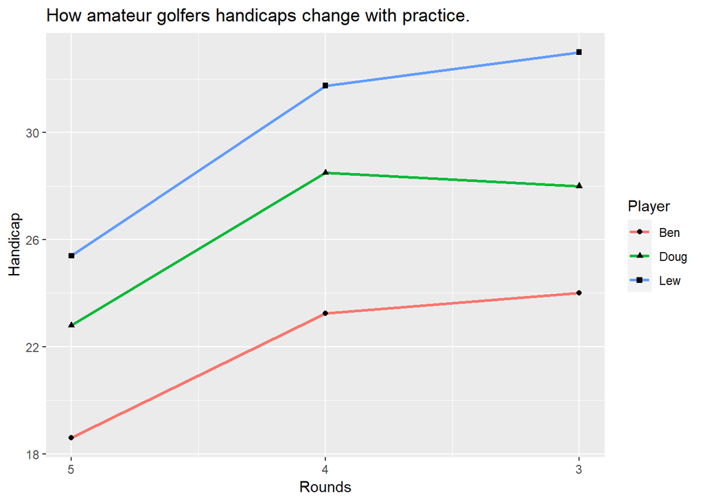

|  | Course |
| --- | --- |
| Ben.Course | Thornbury Long |
| Doug.Course | Thornbury Long |
| Lew.Course | Thornbury Long |